# Ecology 8540 Computational Workshops

May 23, 2021  
Materials at https://github.com/CEIDatUGA/ECOL8540-datavis

## Chart Types

## The goal is to see

“The greatest value of a picture is when it forces us to notice what we never expected to see.”

– John Tukey

## Howard Wainer (1990) on Playfair and Tukey

Legends and annotations can change a weakly good graph into a strongly good graph. Legends and annotations should not just label the graphical objects, but also identify what graphical features are *important*.

## Wald’s bullethold data

Illustrating the issue of *survivorship bias*

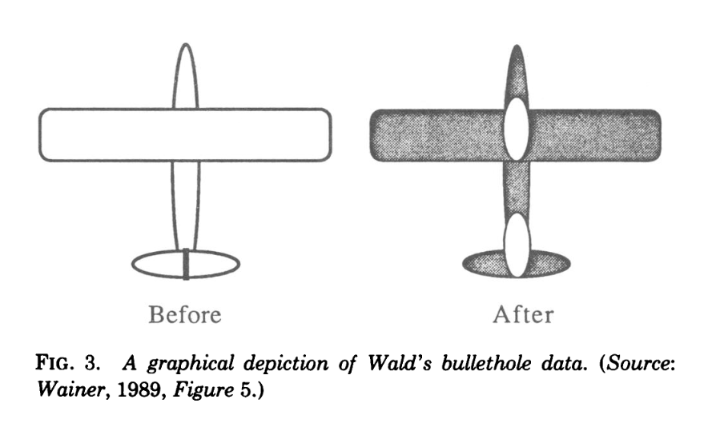

## One variable (distribution data)

## Boxplot concept

[figure not shown]

Source: r-graph-gallery.com

## Boxplot example

[figure not shown]

Source: r-graph-gallery.com

## Probability density function

[figure not shown]

Source: r-graph-gallery.com

## Ridgeline plots

[figure not shown]

Source: r-graph-gallery.com

## Histograms

[figure not shown]

Source: r-graph-gallery.com

## Two-dimensional data

## Scatter plot

[figure not shown]

Source: r-graph-gallery.com

## Scatter plot with trend line

[figure not shown]

Source: r-graph-gallery.com

## Scatter plot with connectors

[figure not shown]

Source: r-graph-gallery.com

## Heat map

Used for displaying a data matrix

[figure not shown]

Source: r-graph-gallery.com

## Modifications to heat map

[figure not shown]

Source: r-graph-gallery.com

## Barplots for a mixture of nominal and quantitative data

[figure not shown]

Source: r-graph-gallery.com

## Grouped barplots

[figure not shown]

Source: r-graph-gallery.com

## Stacked barplots

[figure not shown]

Source: r-graph-gallery.com

## Three-dimensional data

## Bubble plot

[figure not shown]

Source: r-graph-gallery.com

## A bubble plot variation for four-dimensional data

[figure not shown]

Source: r-graph-gallery.com

## Part-whole relationsips

## Pie chart

[figure not shown]

Source: r-graph-gallery.com

## Donut chart

[figure not shown]

Source: r-graph-gallery.com

## Waffle plot

[figure not shown]

Source: r-charts.com

## Hierarchical data

## Treemap

Used for **nested hierarchical** data

[figure not shown]

Source: r-graph-gallery.com

## Dendrogram

Used for **clustered** or **evolutionary** data

[figure not shown]

Source: r-graph-gallery.com

## Circular dendrogram

[figure not shown]

Source: r-graph-gallery.com

## Small multiples (faceting)

[figure not shown]

Source: https://www.r-bloggers.com/2018/04/why-you-should-master-the-small-multiple-chart/

## Pairs plot

[figure not shown]

Source: https://intro2r.com/simple-base-r-plots.html/

## Combination graphs

## A boxplot with jittered data points

[figure not shown]

Source: r-graph-gallery.com

## Scatter plot with marginal distributions

[figure not shown]

Source: r-graph-gallery.com

## Maps

## Choropleth map

[figure not shown]

Source: r-graph-gallery.com

## Hexbin

[figure not shown]

Source: r-graph-gallery.com

## Cartogram

[figure not shown]

Source: r-graph-gallery.com

## Map flows

[figure not shown]

Source: r-graph-gallery.com

## Networks (graphs)

## Undirected graph

[figure not shown]

Source: r-graph-gallery.com

## Directed graph

[figure not shown]

Source: r-graph-gallery.com

## Graphs provide multiple visual channels

[figure not shown]

Source: r-graph-gallery.com